# Aircrafts used in World War 2

Henriette Stenius Wohlin

2022-12-06, updated 09 januar, 2023

## Introduction

The purpose with this paper is to research the variance of the different types of aircraft and make data visualization. Is one type more frequent used than others? Did more aircrafts enter service during the World War II, or was most of them from before the war? Other goals are to compare countries against each other in aircraft type usage and what year the aircraft entered service. If possible, I also wish to find out if this dataset corresponds with events during World War II.

To accomplice this I will work in RStudio. Here I will clean up the dataset and then make data visualizations of the above points. By doing this I hope to inform others more of the different types of aircraft used during the World War II and make the information more accessible to the public.

I acquired the dataset for this project from https://www.kaggle.com/datasets/thomasmuh/world-war-ii-aircrafts?resource=download&select=world_war_2_aircrafts.csv. The csv is listed as world_war_2_aircrafts.csv and includes 1176 Types of WW II Aircrafts. It has 6 columns: Aircraft Type, Aircraft Subtype, Aircraft Name, Year in Service, Country of Origin and Operator(s) if different from country of origin. I needed to create an account on Kaggle.com to gain access to this dataset. There is only one version, Version 1 (116.61 kB), on Kaggle which is the one I used for my project.

The source for the dataset can be found on https://en.wikipedia.org/wiki/ListofaircraftofWorldWarII and it is stated on that the author retrieved in on May 19th, 2019. The Wikipedia page will be used in this assignment to get information on the difference between the aircrafts.

## Setup

Setting up library:

```r
library(tidyverse)
library(RColorBrewer)
```

Making data frame:

```r
aircrafts_ww2 <- read.csv("data/world_war_2_aircrafts.csv")
```

## Cleaning data

Changing column names:

```r
colnames(aircrafts_ww2)[1] = "Aircraft_type"
colnames(aircrafts_ww2)[2] = "Aircraft_subtype"
colnames(aircrafts_ww2)[3] = "Aircraft_name"
colnames(aircrafts_ww2)[4] = "Year_service"
colnames(aircrafts_ww2)[5] = "Country"
```

Source: https://sparkbyexamples.com/r-programming/rename-column-in-r/

Problem: n/a, blank and 1 1930s in Year_service column. We need to fix that in order to change Year_ service column to a numeric one.

```r
aircrafts_ww2$Year_service <- str_replace(aircrafts_ww2$Year_service, "s", "")
```

Source: https://sparkbyexamples.com/r-programming/r-str_replace-to-replace-matched-patterns-in-a-string/

```r
aircrafts_ww2$Year_service <- str_replace(aircrafts_ww2$Year_service, "n/a", "")
```

Replacing blank with NA:

```r
aircrafts_ww2[aircrafts_ww2 == ""] <- NA
```

Source: https://statisticsglobe.com/replace-blank-by-na-in-r

Another problem I found in the data set was that there was a single aircraft that had Germany and Japan listed as their country of origin. I chose to change this to Japan.

```r
aircrafts_ww2$Country <- str_replace(aircrafts_ww2$Country, "Germany, Japan", "Japan")
```

Now I can change the Year_service column to a numeric one:

```r
aircrafts_ww2$Year_service <- as.numeric(as.character(aircrafts_ww2$Year_service))
```

Source: https://stackoverflow.com/questions/37707060/converting-data-frame-column-from-character-to-numeric

“Strategic and photo-reconnaissance aircraft” is a long name so I am changing it to “Strat. and Photo-recon. aircraft”:

```r
aircrafts_ww2$Aircraft_type <- gsub("Strategic and Photo-reconnaissance aircraft", "Strat. and Photo-recon. aircraft", aircrafts_ww2$Aircraft_type)
```

Source: https://stackoverflow.com/questions/50615116/renaming-character-variables-in-a-column-in-data-frame-r

## 1. All aircrafts

First I would like to make a visualization of every aircraft in the data set to find out which has the highest count.

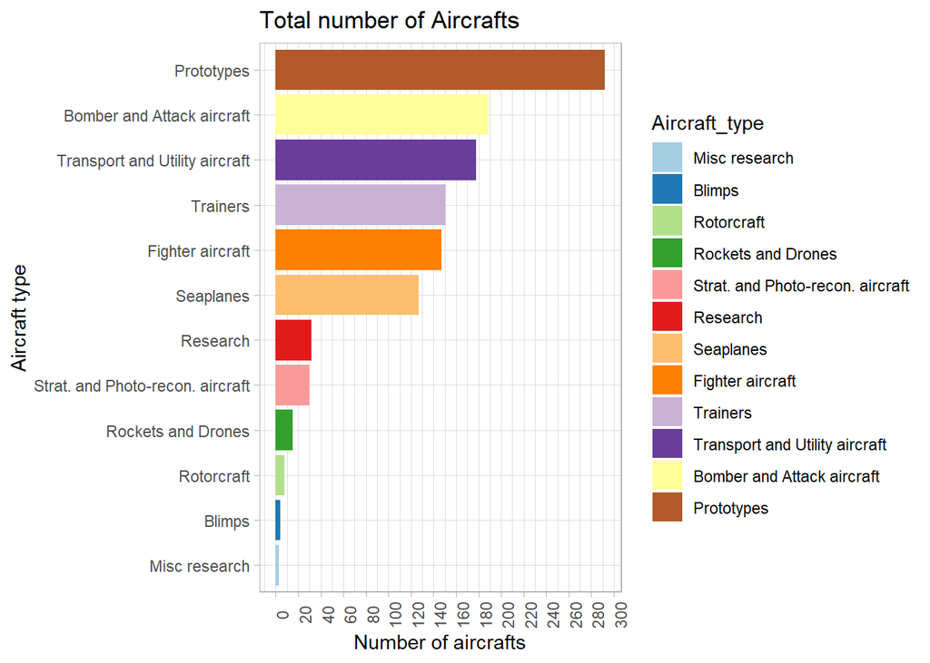

```r
aircrafts_ww2 %>%
  select(Aircraft_type) %>%
  count(Aircraft_type, sort = TRUE) %>%
  mutate(Aircraft_type = fct_reorder(Aircraft_type, n)) %>%
  ggplot(aes(x = n, y = Aircraft_type, fill=Aircraft_type)) +
  scale_fill_brewer(palette="Paired") +
  geom_col() +
  theme_light() +
  labs(title = "Total number of Aircrafts",
       y = "Aircraft type",
       x = "Number of aircrafts") +
  scale_x_continuous(breaks=seq(0,300,20)) +
  theme(axis.text.x = element_text(angle = 90))
```

Source for fct_reorder code: https://r-graph-gallery.com/267-reorder-a-variable-in-ggplot2.html

From this we can see that prototypes have the highest number is quite ahead over the others. Bomber and Attack aircrafts is the second highest with Transport and Utility close by.

## 2. All aircrafts and Country of origin

Now I would like to look at which country produced the most aircrafts.

First we can try for every aircraft:

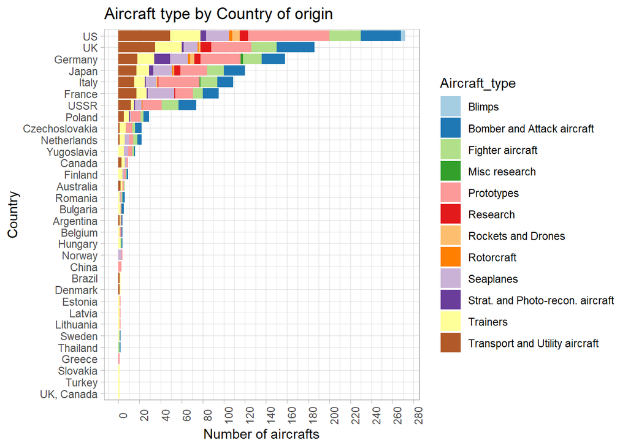

```r
aircrafts_ww2 %>%
  drop_na(Country) %>%
  ggplot(aes(x = fct_rev(fct_infreq(Country)))) +
  geom_bar(aes(fill = Aircraft_type)) +
  scale_fill_brewer(palette="Paired") +
  theme_light() +
  coord_flip() +
  labs(title = "Aircraft type by Country of origin",
       y = "Number of aircrafts",
       x = "Country") +
  scale_y_continuous(breaks=seq(0,300,20)) +
  theme(axis.text.x = element_text(angle = 90))
```

I would like to compare the biggest participants of aircrafts in World War 2, so I will sort it even more:

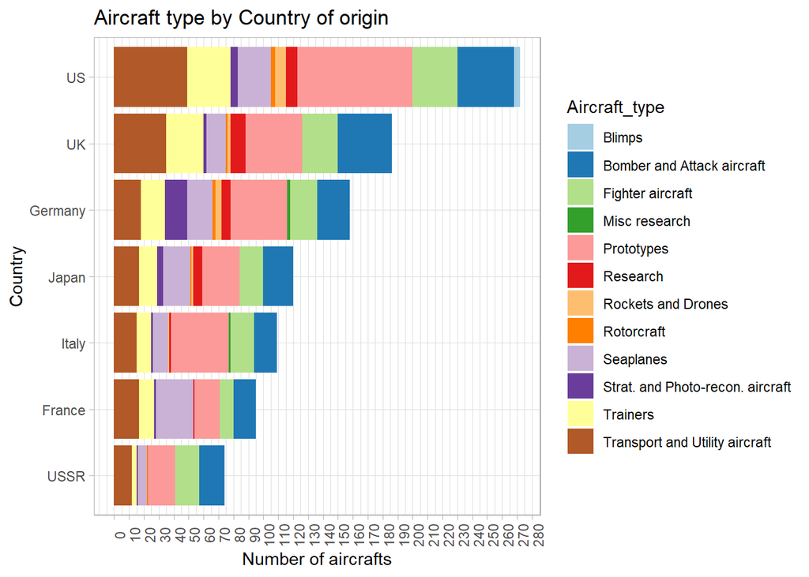

```r
aircrafts_ww2 %>%
  filter(Country %in% c ("US", "UK", "Germany", "Japan", "France", "USSR", "Italy")) %>%
  drop_na(Country) %>%
  ggplot(aes(x = fct_rev(fct_infreq(Country)))) +
  geom_bar(aes(fill = Aircraft_type)) +
  scale_fill_brewer(palette="Paired") +
  theme_light() +
  coord_flip() +
  labs(title = "Aircraft type by Country of origin",
       y = "Number of aircrafts",
       x = "Country") +
    scale_y_continuous(breaks=seq(0,300,10)) +
  theme(axis.text.x = element_text(angle = 90))
```

## 3. All Aircrafts and Year in service

This time I would like to examine the different types of aircrafts and the year that they entered service which means the year the aircraft had its first flight.

Now let us try to visualize it as we have done before with every aircraft:

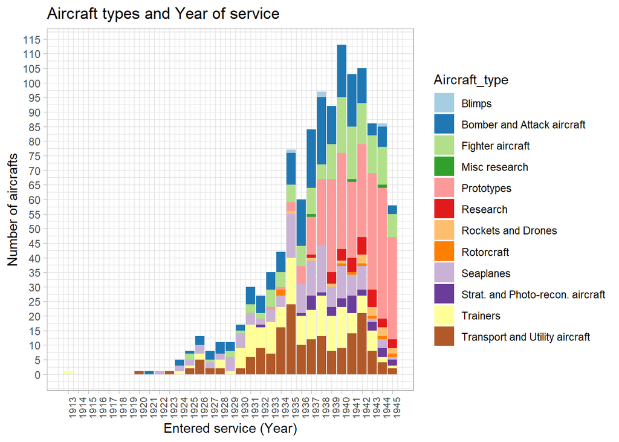

```r
aircrafts_ww2 %>%
  drop_na(Year_service) %>%
  ggplot(aes(x = Year_service)) +
  geom_bar(aes(fill = Aircraft_type)) +
  scale_fill_brewer(palette="Paired") +
  theme_light() +
  labs(title = "Aircraft types and Year of service",
       y = "Number of aircrafts",
       x = "Entered service (Year)") +
    scale_y_continuous(breaks=seq(0,120,5)) +
    scale_x_continuous(breaks=seq(1913,1945,1)) +
    theme(axis.text.x = element_text(angle = 90)) +
    theme(axis.text.x = element_text(size = 8))
```

I would like to try and compare the interwar period and World War 2 to see if there is a difference.

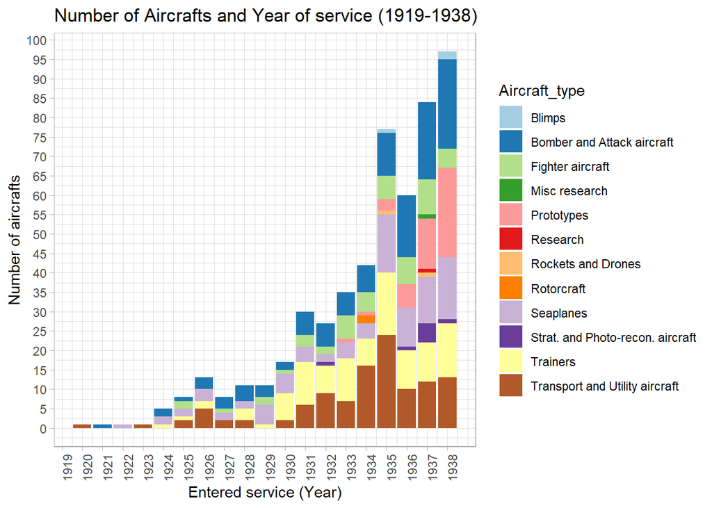

```r
aircrafts_ww2 %>%
  drop_na(Year_service) %>%
  filter(Year_service %in% c("1919","1920", "1921", "1922", "1923", "1924", "1925", "1926", "1926", "1927", "1928", "1929", "1930","1931","1932","1933", "1934","1935", "1936", "1937","1938")) %>%
  ggplot(aes(x = Year_service)) +
  geom_bar(aes(fill = Aircraft_type)) +
  scale_fill_brewer(palette="Paired") +
  theme_light() +
  labs(title = "Number of Aircrafts and Year of service (1919-1938)",
       y = "Number of aircrafts",
       x = "Entered service (Year)") +
    scale_y_continuous(breaks=seq(0,120,5)) +
    scale_x_continuous(breaks=seq(1919,1938,1)) +
    theme(axis.text.x = element_text(angle = 90))
```

World War 2 (1939-1945):

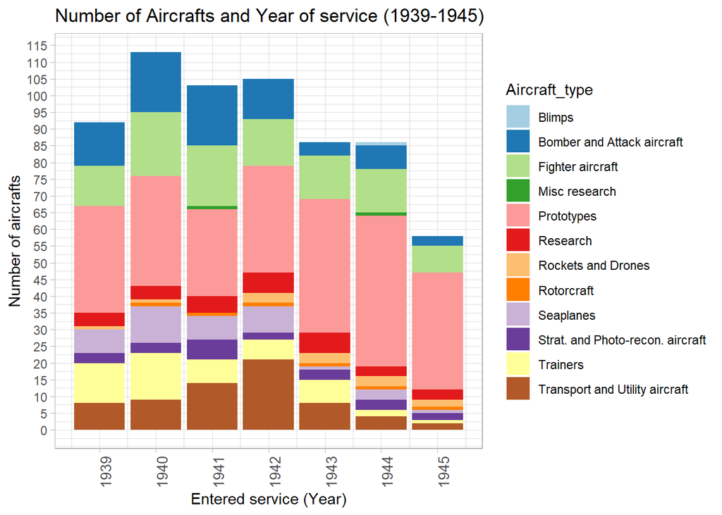

```r
aircrafts_ww2 %>%
  drop_na(Year_service) %>%
  filter(Year_service %in% c("1939", "1940", "1941", "1942", "1943", "1944", "1945")) %>%
  ggplot(aes(x = Year_service)) +
  geom_bar(aes(fill = Aircraft_type)) +
  scale_fill_brewer(palette="Paired") +
  theme_light() +
  labs(title = "Number of Aircrafts and Year of service (1939-1945)",
       y = "Number of aircrafts",
       x = "Entered service (Year)") +
    scale_y_continuous(breaks=seq(0,120,5)) +
    scale_x_continuous(breaks=seq(1939,1945,1)) +
    theme(axis.text.x = element_text(angle = 90)) +
    theme(axis.text.x = element_text(size = 10))
```

If we compare these two graphs it does show that there was an increase in the number of aircrafts being produced during the second war. More aircrafts being produced while war is being fought also makes sense as many aircrafts get destroyed during war – aircrafts were always evolving to be better than the last and aircrafts from before 1938 might not have cut it anymore.

Production of new aircrafts seems to slow down at 1943-1944. At 1945 production falls drastically which was most likely as the war was near its end.

## 4. All Aircrafts and Year in service by specific Country of Origin

Now I would to visualize the biggest participants of aircrafts in World War 2 by their Year of service and what types of Aircrafts they made:

USA:

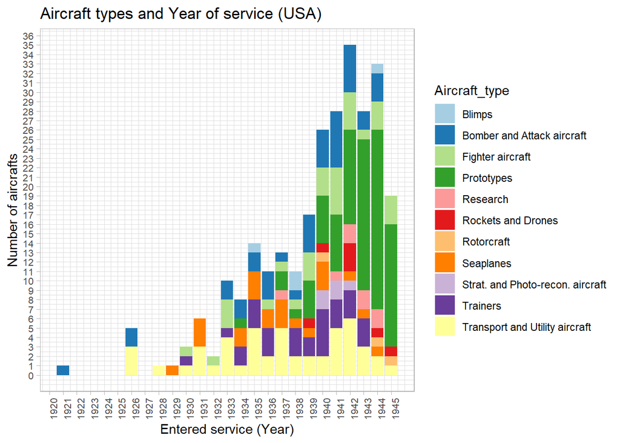

```r
aircrafts_ww2 %>%
  filter(Country %in% c ("US")) %>%
  drop_na(Country) %>%
  drop_na(Year_service) %>%
  ggplot(aes(x = Year_service)) +
  geom_bar(aes(fill = Aircraft_type)) +
  scale_fill_brewer(palette="Paired") +
  theme_light() +
  labs(title = "Aircraft types and Year of service (USA)",
       y = "Number of aircrafts",
       x = "Entered service (Year)") +
    scale_y_continuous(breaks=seq(0,40,1)) +
    scale_x_continuous(breaks=seq(1913,1945,1)) +
    theme(axis.text.x = element_text(angle = 90)) +
    theme(axis.text.x = element_text(size = 8)) +
  theme(axis.text.y = element_text(size = 8))
```

United Kingdom:

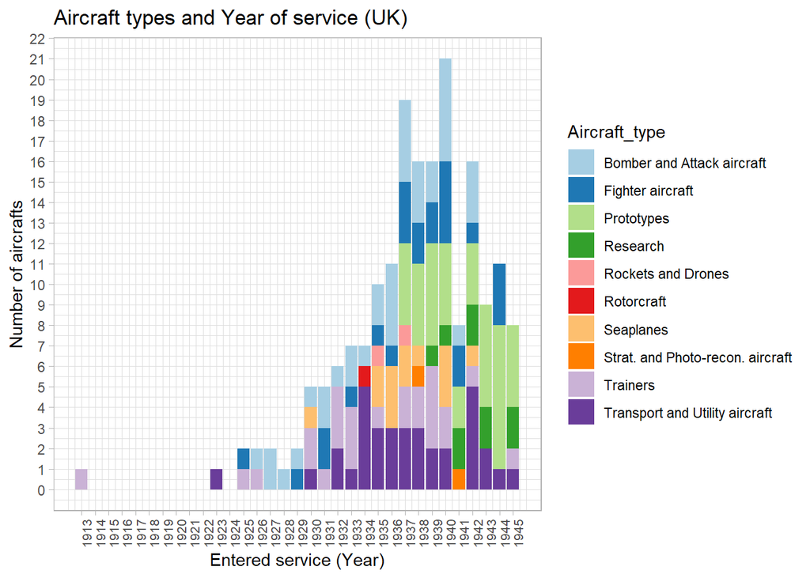

```r
aircrafts_ww2 %>%
  filter(Country %in% c ("UK")) %>%
  drop_na(Country) %>%
  drop_na(Year_service) %>%
  ggplot(aes(x = Year_service)) +
  geom_bar(aes(fill = Aircraft_type)) +
  scale_fill_brewer(palette="Paired") +
  theme_light() +
  labs(title = "Aircraft types and Year of service (UK)",
       y = "Number of aircrafts",
       x = "Entered service (Year)") +
    scale_y_continuous(breaks=seq(0,30,1)) +
    scale_x_continuous(breaks=seq(1913,1945,1)) +
    theme(axis.text.x = element_text(angle = 90)) +
    theme(axis.text.x = element_text(size = 8))
```

Germany:

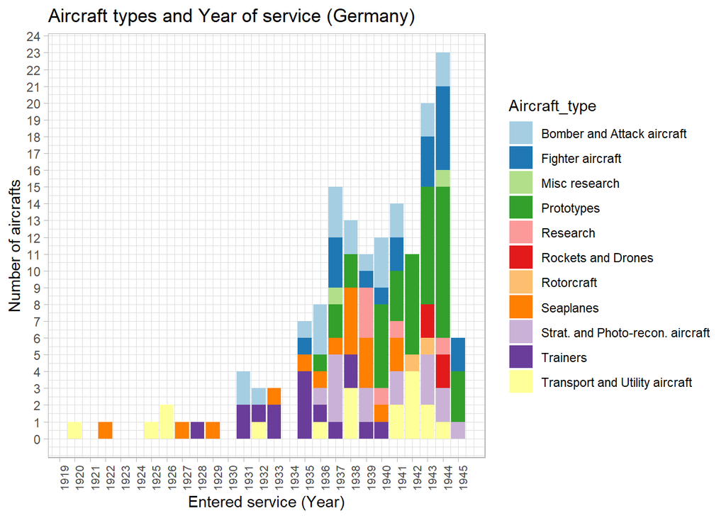

```r
aircrafts_ww2 %>%
  filter(Country %in% c ("Germany")) %>%
  drop_na(Country) %>%
  drop_na(Year_service) %>%
  ggplot(aes(x = Year_service)) +
  geom_bar(aes(fill = Aircraft_type)) +
  theme_light() +
  scale_fill_brewer(palette="Paired") +
  labs(title = "Aircraft types and Year of service (Germany)",
       y = "Number of aircrafts",
       x = "Entered service (Year)") +
    scale_y_continuous(breaks=seq(0,30,1)) +
    scale_x_continuous(breaks=seq(1913,1945,1)) +
    theme(axis.text.x = element_text(angle = 90)) +
    theme(axis.text.x = element_text(size = 8))
```

Japan:

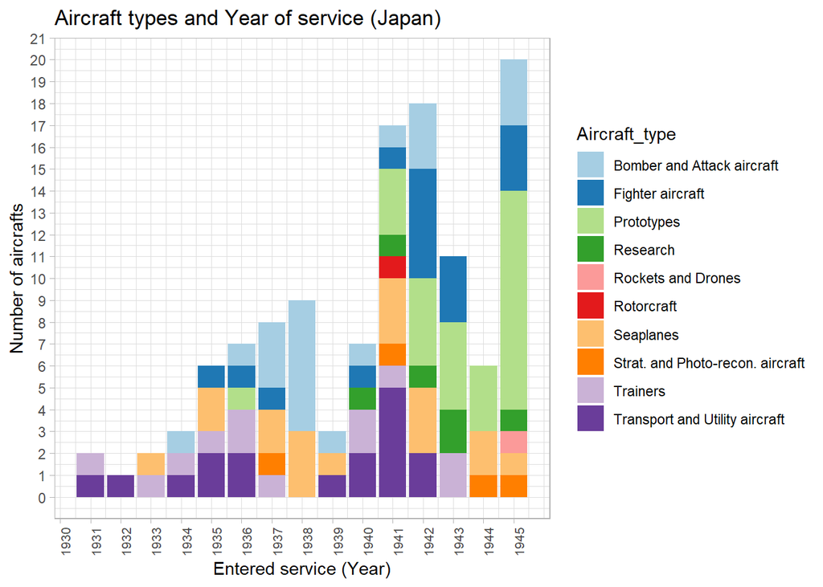

```r
aircrafts_ww2 %>%
  filter(Country %in% c ("Japan")) %>%
  drop_na(Country) %>%
  drop_na(Year_service) %>%
  ggplot(aes(x = Year_service)) +
  scale_fill_brewer(palette="Paired") +
  geom_bar(aes(fill = Aircraft_type)) +
  theme_light() +
  labs(title = "Aircraft types and Year of service (Japan)",
       y = "Number of aircrafts",
       x = "Entered service (Year)") +
    scale_y_continuous(breaks=seq(0,30,1)) +
    scale_x_continuous(breaks=seq(1913,1945,1)) +
    theme(axis.text.x = element_text(angle = 90)) +
    theme(axis.text.x = element_text(size = 8))
```

Italy:

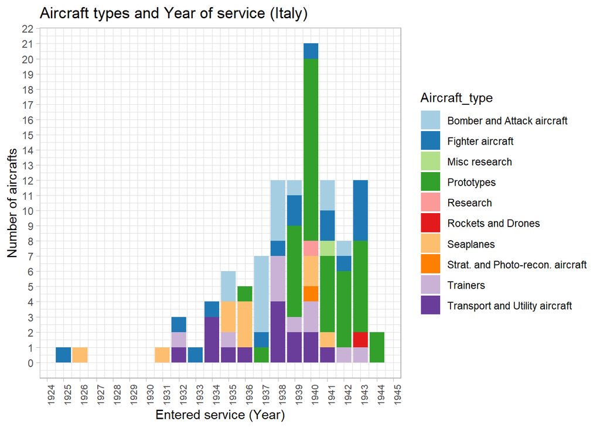

```r
aircrafts_ww2 %>%
  filter(Country %in% c ("Italy")) %>%
  drop_na(Country) %>%
  drop_na(Year_service) %>%
  ggplot(aes(x = Year_service)) +
  geom_bar(aes(fill = Aircraft_type)) +
  scale_fill_brewer(palette="Paired") +
  theme_light() +
  labs(title = "Aircraft types and Year of service (Italy)",
       y = "Number of aircrafts",
       x = "Entered service (Year)") +
    scale_y_continuous(breaks=seq(0,30,1)) +
    scale_x_continuous(breaks=seq(1913,1945,1)) +
    theme(axis.text.x = element_text(angle = 90)) +
    theme(axis.text.x = element_text(size = 8))
```

France:

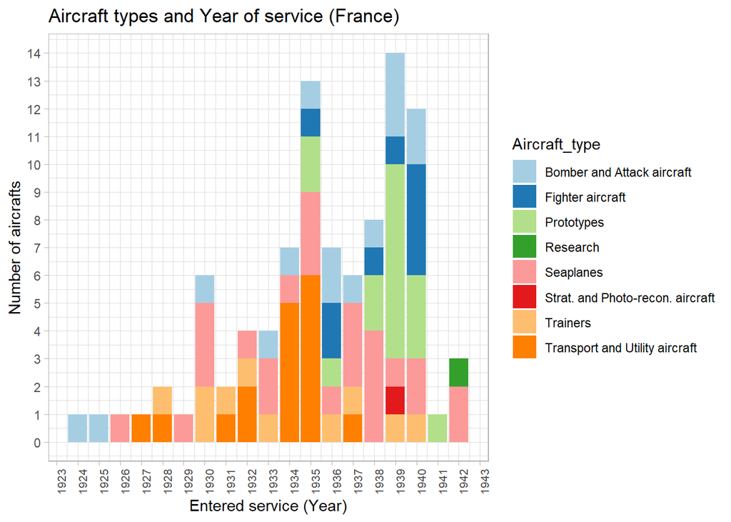

```r
aircrafts_ww2 %>%
  filter(Country %in% c ("France")) %>%
  drop_na(Country) %>%
  drop_na(Year_service) %>%
  ggplot(aes(x = Year_service)) +
  scale_fill_brewer(palette="Paired") +
  geom_bar(aes(fill = Aircraft_type)) +
  theme_light() +
  labs(title = "Aircraft types and Year of service (France)",
       y = "Number of aircrafts",
       x = "Entered service (Year)") +
    scale_y_continuous(breaks=seq(0,30,1)) +
    scale_x_continuous(breaks=seq(1913,1945,1)) +
    theme(axis.text.x = element_text(angle = 90)) +
    theme(axis.text.x = element_text(size = 8))
```

USSR:

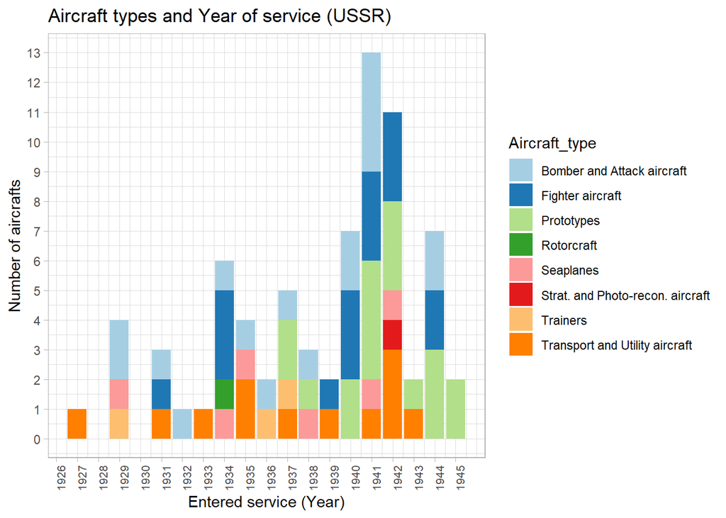

```r
aircrafts_ww2 %>%
  filter(Country %in% c ("USSR")) %>%
  drop_na(Country) %>%
  drop_na(Year_service) %>%
  ggplot(aes(x = Year_service)) +
  geom_bar(aes(fill = Aircraft_type)) +
  scale_fill_brewer(palette="Paired") +
  theme_light() +
  labs(title = "Aircraft types and Year of service (USSR)",
       y = "Number of aircrafts",
       x = "Entered service (Year)") +
    scale_y_continuous(breaks=seq(0,20,1)) +
    scale_x_continuous(breaks=seq(1913,1945,1)) +
    theme(axis.text.x = element_text(angle = 90)) +
    theme(axis.text.x = element_text(size = 8))
```